# Aides Drug

celia diaz

11/18/19

# Introduction

# Methods

## Question 1: is the vaccine effective for the total population?

$H_o$ the vaccine has no effect on whether one contracts aides or not $H_1$ the vaccine affects whether one contracts aids or not

## Question 2:is the vaccine effective for the LGBTQ population?

$H_o$ the vaccine has no effect on whether one contracts Aids or not $H-1$ the vaccine affect whether one contracts aids or not

## Question 3: is the vaccine effective for drug users?

$H_o$ the vaccine has no effect on whether one contracts aids or not $H_1$ the vaccine affects whether one contracts aids or not

## Question 4: is the vaccine effective in men?

$H_o$ the vaccine has no effect whether one contracts aids or not $H_1$ the vaccine affects whether one contracts aids or not

## Question 5 is the vaccine effective in females?

$H_o$ the vaccine has no effect whether one contracts aids or not $H_1$ the vaccine affects whether one contracts aids or not

# Results

## Descriptive Results

### Graphical Descriptive Results

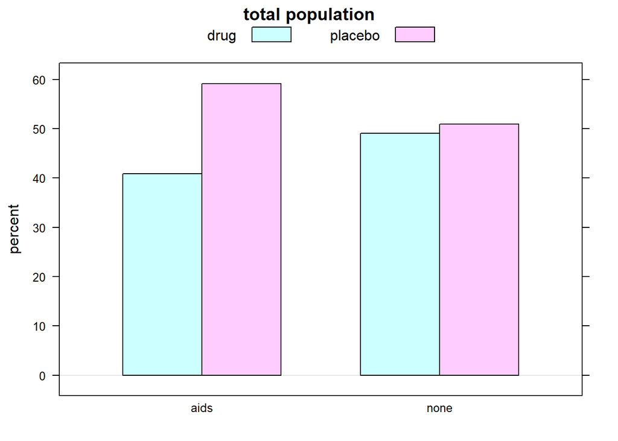

```r
barchartGC (~infected +treatment, data = avast,type = "percent",main ="total population")
```

This bar chart shows that for the total population the drug is working to prevent the aids infection since it is lower than that of the placebo group infected by aids.

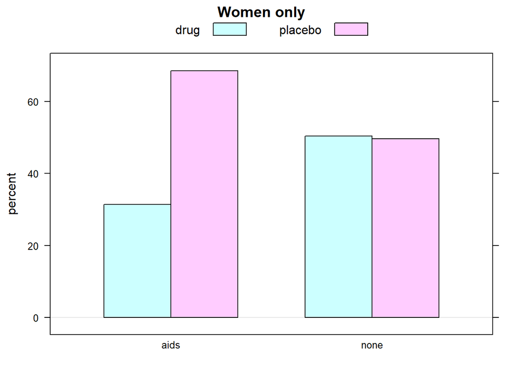

```r
barchartGC(~infected + treatment, data = filter(avast, sex =='gal'), main = 'Women only', type = 'percent')
```

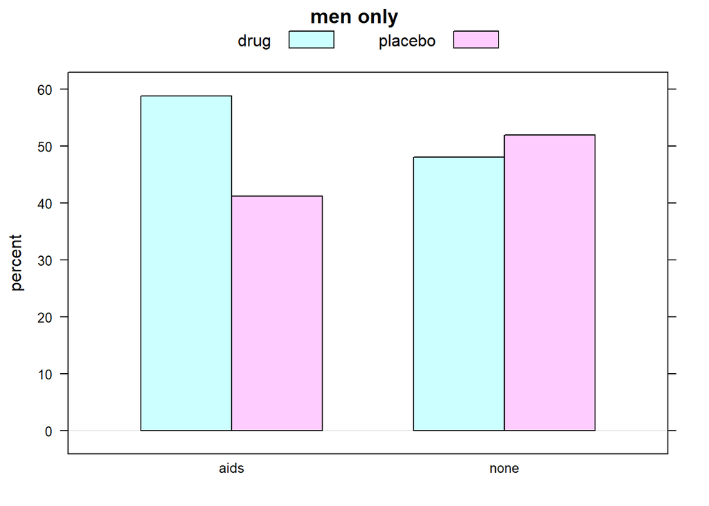

```r
barchartGC(~infected + treatment, data = filter(avast, sex =='guy'), main = 'men only', type = 'percent')
```

The bar chart shows that for the men the drug group is higher, thus putting the men at an increased risk of contracting the aids infection.

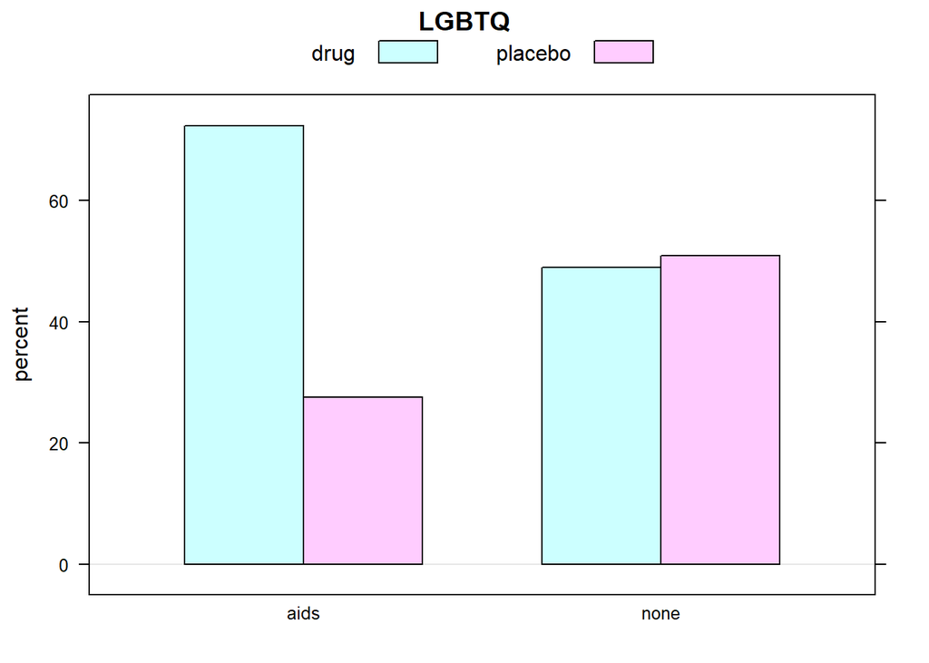

```r
barchartGC(~infected + treatment, data = filter(avast, LGBTQ =='gay'), main = 'LGBTQ', type = 'percent')
```

The bar chart shows that for the LGBTQ community the drug group is higher, thus putting the LGBTQ community at an increased risk of contracting the aids infection.

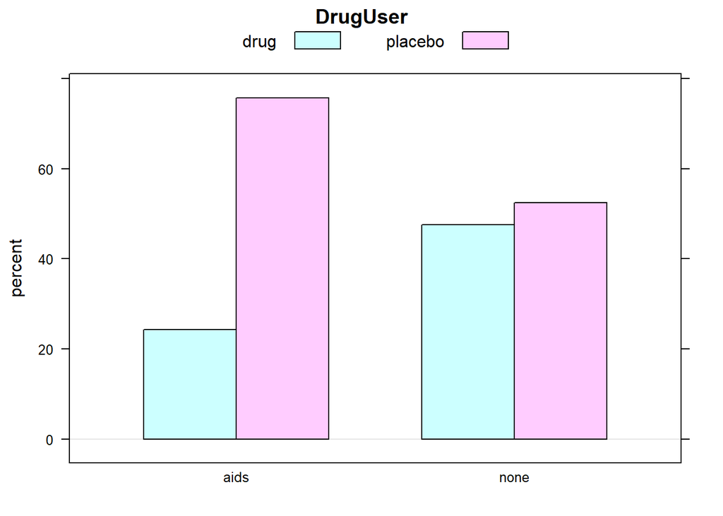

```r
barchartGC(~infected + treatment, data = filter(avast, DrugUser=='yes'), main = 'DrugUser', type = 'percent')
```

The bar graph shows that for drug users the drug group is lower thus the drug is working to prevent the AIDS infection.

### Numerical Descriptive Results

```r
LGBTQ = xtabs(~infected + treatment, data = filter(avast, LGBTQ =='gay'))
rowPerc(LGBTQ)
```

```
##         treatment
## infected   drug placebo  Total
##     aids  72.38   27.62 100.00
##     none  49.05   50.95 100.00
```

The table shows that there is a 44% difference between the drug group and the placebo group. Thus putting the LGBTQ community at a higher risk of contracting the aids infection.

```r
females = xtabs(~infected + treatment, data = filter(avast, sex =="gal"))
rowPerc(females)
```

```
##         treatment
## infected   drug placebo  Total
##     aids  31.42   68.58 100.00
##     none  50.38   49.62 100.00
```

The table shows that there is 37% difference between the placebo group and the drug users group. In this case the placebo group has a higher percentage.

```r
males = xtabs(~infected + treatment, data = filter(avast, sex == "guy"))
rowPerc(males)
```

```
##         treatment
## infected   drug placebo  Total
##     aids  58.82   41.18 100.00
##     none  48.06   51.94 100.00
```

The table shows that there is a 17% difference between the drug group and the placebo group.Thus placing the males at higher risk of becoming infected.

```r
DrugUser = xtabs(~infected + treatment, data = filter(avast, DrugUser == "yes"))
rowPerc(DrugUser)
```

```
##         treatment
## infected   drug placebo  Total
##     aids  24.29   75.71 100.00
##     none  47.59   52.41 100.00
```

The table shows that there is a 51% difference between the placebo group and the drug group. Thus putting the drug users at a lower risk of contracting the AIDS infection.

```r
allPeople = xtabs (~infected +treatment, data = avast)
rowPerc(allPeople)
```

```
##         treatment
## infected   drug placebo  Total
##     aids  40.87   59.13 100.00
##     none  49.10   50.90 100.00
```

This table shows that there is a 19% difference amongst the drug users and the placebo group. The placebo group is at a higher percentage than the drug user

## Inferential Results

```r
chisqtestGC(allPeople, data = avast)
```

```
## Pearson's Chi-squared test with Yates' continuity correction
##
## Observed Counts:
##         treatment
## infected  drug placebo
##     aids   423     612
##     none 10168   10540
##
## Counts Expected by Null:
##         treatment
## infected     drug  placebo
##     aids   504.15   530.85
##     none 10086.85 10621.15
##
## Contributions to the chi-square statistic:
##         treatment
## infected  drug placebo
##     aids 13.06   12.40
##     none  0.65    0.62
##
##
## Chi-Square Statistic = 26.4104
## Degrees of Freedom of the table = 1
## P-Value = 0
```

The p-value is 0, < 0,05 so we reject the null hypothesis and conclude the vaccine is effective in preventing one from getting AIDS in the general population

```r
chisqtestGC(females, data = gals)
```

```
## Pearson's Chi-squared test with Yates' continuity correction
##
## Observed Counts:
##         treatment
## infected drug placebo
##     aids  213     465
##     none 4684    4613
##
## Counts Expected by Null:
##         treatment
## infected    drug placebo
##     aids  332.85  345.15
##     none 4564.15 4732.85
##
## Contributions to the chi-square statistic:
##         treatment
## infected  drug placebo
##     aids 43.15   41.62
##     none  3.15    3.03
##
##
## Chi-Square Statistic = 90.1943
## Degrees of Freedom of the table = 1
## P-Value = 0
```

The p-value is 0, < 0,05 so we reject the null hypothesis and conclued the vaccine is effective in preventing one from getting AIDS in the female population.

```r
chisqtestGC(males, data = guy)
```

```
## Pearson's Chi-squared test with Yates' continuity correction
##
## Observed Counts:
##         treatment
## infected drug placebo
##     aids  210     147
##     none 5484    5927
##
## Counts Expected by Null:
##         treatment
## infected    drug placebo
##     aids  172.74  184.26
##     none 5521.26 5889.74
##
## Contributions to the chi-square statistic:
##         treatment
## infected drug placebo
##     aids 8.04    7.54
##     none 0.25    0.24
##
##
## Chi-Square Statistic = 15.6339
## Degrees of Freedom of the table = 1
## P-Value = 1e-04
```

```r
chisqtestGC(LGBTQ, data = gay)
```

```
## Pearson's Chi-squared test with Yates' continuity correction
##
## Observed Counts:
##         treatment
## infected drug placebo
##     aids   76      29
##     none 1007    1046
##
## Counts Expected by Null:
##         treatment
## infected    drug placebo
##     aids   52.69   52.31
##     none 1030.31 1022.69
##
## Contributions to the chi-square statistic:
##         treatment
## infected  drug placebo
##     aids 10.31   10.38
##     none  0.53    0.53
##
##
## Chi-Square Statistic = 20.8264
## Degrees of Freedom of the table = 1
## P-Value = 0
```

```r
chisqtestGC(DrugUser, data = yes )
```

```
## Pearson's Chi-squared test with Yates' continuity correction
##
## Observed Counts:
##         treatment
## infected drug placebo
##     aids   34     106
##     none 1143    1259
##
## Counts Expected by Null:
##         treatment
## infected    drug placebo
##     aids   64.82   75.18
##     none 1112.18 1289.82
##
## Contributions to the chi-square statistic:
##         treatment
## infected  drug placebo
##     aids 14.66   12.64
##     none  0.85    0.74
##
##
## Chi-Square Statistic = 27.955
## Degrees of Freedom of the table = 1
## P-Value = 0
```

The p-value is 0, < 0,05 so we reject the null hypothesis and conclude the vaccine is effective in preventing the Drug users from getting AIDS.

# Discussion and Conclusion

In conclusion, between the female population, the total population, and the drug users the drug helped them in preventing the contraction of AIDS. However, in looking at the LGBTQ and male groups the drug put them at risk of contacting AIDS.